# Kraken

| **Model** | `AcousticsToolbox.Kraken` |
| --- | --- |
| **Description** | [Kraken and KrakenC normal mode models](https://oalib-acoustics.org/models-and-software/normal-modes/) (wrapper) |
| **Language** | Fortran |
| **Advantages** | Well-established benchmark models |
| **Limitations** | Not differentiable |

```
Kraken(env; kwargs...)
```

Create a Kraken propagation model.

Supported keyword arguments:

- `nmodes`: number of modes to use (default: 9999)
- `mesh_density`: number of mesh points per wavelength (default: 0, 0=auto)
- `clow`: lower limit of phase speed (default: 1300, 0=auto)
- `chigh`: upper limit of phase speed (default: 2500)
- `rmax`: largest range (in m) of interest (default: Inf)
- `complex_solver`: use KrakenC for finding modes (default: true)
- `robust`: use robust (but slow) root finder (default: false)
- `temp_dir`: directory for temporary files (default: system temp directory)
- `debug`: debug mode (default: false)

Enabling debug mode will create a temporary directory with the Kraken input and output files. This allows manual inspection of the files.

The default `rmax` is set to `Inf`. With this setting, it actually uses a value 1% more than furthest receiver. Setting `rmax` to 0 asks underlying FORTRAN Kraken model to automatically choose `rmax`. While the Kraken manual suggests it, we find that this option often gives poor results and do not recommend its use.

A good overview of the Kraken model can be found at:

- M. B. Porter, “The KRAKEN normal mode program”, Technical report NRL/MR/5120-92-6920, Naval Research Laboratory, 1992 [(original report pdf)](https://apps.dtic.mil/sti/tr/pdf/ADA252409.pdf) [(updated draft pdf)](https://oalib-acoustics.org/website_resources/Modes/kraken.pdf).

**Tip**

The theory of modal models is summarized in a brief note “On modal models”. It provides an overview of key concepts and relevant mathematical formulations.

## Examples

### Range-independent scenario

Here’s an example showing results for the PEKERIS test problem from the Kraken technical report:

```julia
using UnderwaterAcoustics
using AcousticsToolbox
using Plots

env = UnderwaterEnvironment(
  bathymetry = 5000,
  soundspeed = 1500,
  density = 1000,
  seabed = FluidBoundary(2000, 2000)
)
pm = Kraken(env)

tx = AcousticSource(0, -500, 10)
rx = AcousticReceiver(200000, -2500)
modes = arrivals(pm, tx, rx)[1:7]     # first 7 modes
```

```
7 element Vector{ModeArrival}:
  mode 1: kᵣ = 0.041883 - 0.0im rad/m, v = 1499.84 m/s, vₚ = 1500.16 m/s
  mode 2: kᵣ = 0.04187 - 0.0im rad/m, v = 1499.36 m/s, vₚ = 1500.66 m/s
  mode 3: kᵣ = 0.041847 - 0.0im rad/m, v = 1498.56 m/s, vₚ = 1501.48 m/s
  mode 4: kᵣ = 0.041815 - 0.0im rad/m, v = 1497.45 m/s, vₚ = 1502.63 m/s
  mode 5: kᵣ = 0.041773 - 0.0im rad/m, v = 1496.01 m/s, vₚ = 1504.12 m/s
  mode 6: kᵣ = 0.041723 - 0.0im rad/m, v = 1494.24 m/s, vₚ = 1505.94 m/s
  mode 7: kᵣ = 0.041663 - 0.0im rad/m, v = 1492.15 m/s, vₚ = 1508.10 m/s
```

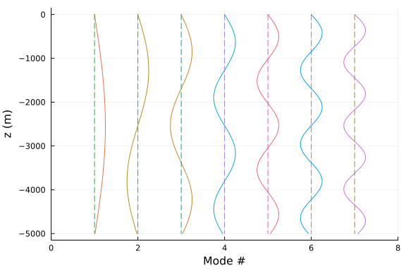

```julia
# plot the modes
plot(modes)
```

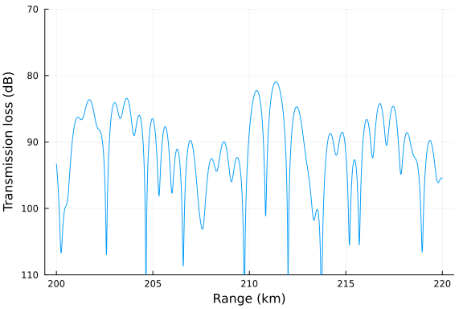

```julia
rxs = AcousticReceiverGrid2D(200000:10:220000, -2500)
x = transmission_loss(pm, tx, rxs)

plot(200:0.01:220, x; ylims=(70,110), yflip=true, legend=false,
  xlabel="Range (km)", ylabel="Transmission loss (dB)")
```

### Range-dependent scenario with multilayered seabed

While the Kraken model is range-independent by itself, it can be made range-dependent by using `AdiabaticExt` as shown below:

```julia
using UnderwaterAcoustics
using Plots

env = UnderwaterEnvironment(
  bathymetry = SampledField([200, 150, 200]; x=[0, 2000, 5000]),
  soundspeed = 1500,
  density = 1000,
  seabed = MultilayerElasticBoundary([
    (40, 1374, 1520, 0, dBperλ(0.1124), 0),           # 40m thick fluid sediment
    (Inf, 2200, 1730, 800, dBperλ(0.5), dBperλ(0.5))  # hard half-space substrate
  ])
)

# use an adiabatic extension to the Kraken for range-dependence
pm = AdiabaticExt(Kraken, env)

tx = AcousticSource(0, -50, 250)
rx = AcousticReceiver(7000, -25)
modes = arrivals(pm, tx, rx)[1:7]      # first 7 modes
```

```
7 element Vector{ModeArrival}:
  mode 1: kᵣ = 1.047089 - 1.0e-6im rad/m, v = 1499.83 m/s, vₚ = 1500.16 m/s
  mode 2: kᵣ = 1.046762 - 3.0e-6im rad/m, v = 1499.30 m/s, vₚ = 1500.62 m/s
  mode 3: kᵣ = 1.046217 - 6.0e-6im rad/m, v = 1498.42 m/s, vₚ = 1501.41 m/s
  mode 4: kᵣ = 1.045452 - 1.0e-5im rad/m, v = 1497.19 m/s, vₚ = 1502.50 m/s
  mode 5: kᵣ = 1.044468 - 1.6e-5im rad/m, v = 1495.60 m/s, vₚ = 1503.92 m/s
  mode 6: kᵣ = 1.043263 - 2.2e-5im rad/m, v = 1493.65 m/s, vₚ = 1505.66 m/s
  mode 7: kᵣ = 1.041837 - 3.1e-5im rad/m, v = 1491.37 m/s, vₚ = 1507.72 m/s
```

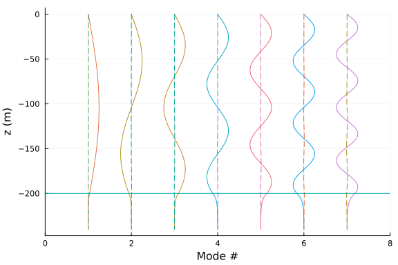

```julia
# plot the modes at 7 km range
plot(modes)
hline!([-200])    # seabed location
```

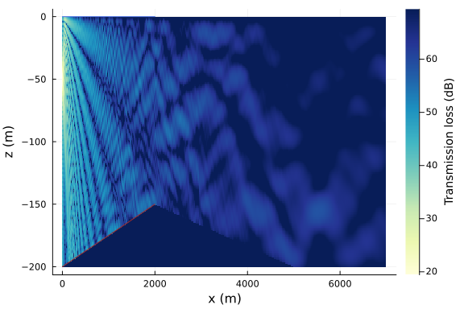

```julia
rxs = AcousticReceiverGrid2D(10:10:7000, -200:-1)
x = transmission_loss(pm, tx, rxs)

plot(rxs, x; crange=50)
plot!(env)
```

## Notes

The Fortran Kraken propagation model requires that the transmitter is located at $(x=0, y=0)$ and all receivers are located in the right half-plane (i.e., $x>0$ and $y=0$). This limitation can be worked around by wrapping the model with `Reframe2D`, which automatically transforms 2D scenarios specified in world coordinates into the coordinate system required by the model (see the quickstart guide for an example).

Additionally, this wrapper does not yet support all the features of the original Fortran model. In particular, it does NOT support:

- N2-linear, analytic or quadratic interpolation for sound speed
- Arbitrary reflection coefficients
- Twersky scattering

Receivers on an irregular grid are supported, but not currently optimized for speed (by using the irregular grid option in the Fortran model).

Kraken currently does not compute modal group velocities. While KrakenC does compute group velocities, the values are incorrect for multilayer seabeds with elastic sediment layers. In both cases, when group velocities are unavailable, the returned modes will not include group velocity information (will be reported as `missing`).